# Bob Ross Paintings

Wei Yue Hung

2023-12-12

```r
library(tidyverse)
library(knitr)
library(dplyr)
library(widyr)
library(ggraph)
library(igraph)
theme_set(theme_minimal())
```

## Reading and cleaning the data

```r
bob_ross <- readr::read_csv('https://raw.githubusercontent.com/rfordatascience/tidytuesday/master/data/2023/2023-02-21/bob_ross.csv')
hex_color <- c('#4E1500', '#000000', '#DB0000', '#8A3324', '#FFEC00', '#5F2E1F', '#CD5C5C', '#FFB800', '#000000', '#FFFFFF', '#000000', '#0C0040', '#102E3C', '#021E44', '#0A3410', '#FFFFFF', '#221B15', '#C79B00')
# Checking the data structure
glimpse(bob_ross)
```

```
## Rows: 403
## Columns: 27
## $ painting_index   <dbl> 282, 283, 284, 285, 286, 287, 288, 289, 290, 291, 292…
## $ img_src          <chr> "https://www.twoinchbrush.com/images/painting282.png"…
## $ painting_title   <chr> "A Walk in the Woods", "Mt. McKinley", "Ebony Sunset"…
## $ season           <dbl> 1, 1, 1, 1, 1, 1, 1, 1, 1, 1, 1, 1, 1, 2, 2, 2, 2, 2,…
## $ episode          <dbl> 1, 2, 3, 4, 5, 6, 7, 8, 9, 10, 11, 12, 13, 1, 2, 3, 4…
## $ num_colors       <dbl> 8, 8, 9, 3, 8, 4, 8, 8, 8, 8, 8, 4, 8, 12, 12, 13, 3,…
## $ youtube_src      <chr> "https://www.youtube.com/embed/oh5p5f5_-7A", "https:/…
## $ colors           <chr> "['Alizarin Crimson', 'Bright Red', 'Cadmium Yellow',…
## $ color_hex        <chr> "['#4E1500', '#DB0000', '#FFEC00', '#102E3C', '#021E4…
## $ Black_Gesso      <lgl> FALSE, FALSE, TRUE, FALSE, FALSE, TRUE, FALSE, FALSE,…
## $ Bright_Red       <lgl> TRUE, TRUE, TRUE, FALSE, TRUE, FALSE, TRUE, TRUE, TRU…
## $ Burnt_Umber      <lgl> FALSE, FALSE, FALSE, FALSE, FALSE, FALSE, FALSE, FALS…
## $ Cadmium_Yellow   <lgl> TRUE, TRUE, TRUE, FALSE, TRUE, FALSE, TRUE, TRUE, TRU…
## $ Dark_Sienna      <lgl> FALSE, FALSE, FALSE, FALSE, FALSE, FALSE, FALSE, FALS…
## $ Indian_Red       <lgl> FALSE, FALSE, FALSE, FALSE, FALSE, FALSE, FALSE, FALS…
## $ Indian_Yellow    <lgl> FALSE, FALSE, FALSE, FALSE, FALSE, FALSE, FALSE, FALS…
## $ Liquid_Black     <lgl> FALSE, FALSE, FALSE, FALSE, FALSE, FALSE, FALSE, FALS…
## $ Liquid_Clear     <lgl> FALSE, FALSE, FALSE, FALSE, FALSE, FALSE, FALSE, FALS…
## $ Midnight_Black   <lgl> FALSE, FALSE, FALSE, FALSE, FALSE, FALSE, FALSE, FALS…
## $ Phthalo_Blue     <lgl> FALSE, FALSE, FALSE, FALSE, FALSE, FALSE, FALSE, FALS…
## $ Phthalo_Green    <lgl> TRUE, TRUE, TRUE, FALSE, TRUE, FALSE, TRUE, TRUE, TRU…
## $ Prussian_Blue    <lgl> TRUE, TRUE, TRUE, TRUE, TRUE, TRUE, TRUE, TRUE, TRUE,…
## $ Sap_Green        <lgl> TRUE, TRUE, TRUE, FALSE, TRUE, FALSE, TRUE, TRUE, TRU…
## $ Titanium_White   <lgl> TRUE, TRUE, TRUE, TRUE, TRUE, TRUE, TRUE, TRUE, TRUE,…
## $ Van_Dyke_Brown   <lgl> TRUE, TRUE, TRUE, TRUE, TRUE, TRUE, TRUE, TRUE, TRUE,…
## $ Yellow_Ochre     <lgl> FALSE, FALSE, FALSE, FALSE, FALSE, FALSE, FALSE, FALS…
## $ Alizarin_Crimson <lgl> TRUE, TRUE, TRUE, FALSE, TRUE, FALSE, TRUE, TRUE, TRU…
```

## Exploratory Data Analysis

```r
summary(bob_ross$num_colors)
```

```
##    Min. 1st Qu.  Median    Mean 3rd Qu.    Max.
##    1.00    9.00   11.00   10.61   12.00   15.00
```

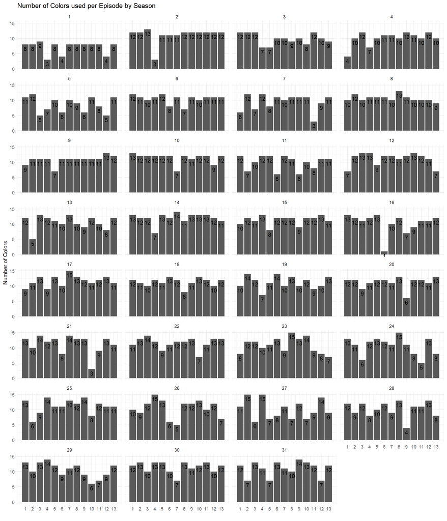

```r
ggplot(bob_ross, aes(x = episode, y = num_colors)) +
  geom_col() +
  geom_text(aes(label = num_colors), vjust = 1.5)+
  facet_wrap(~ season, ncol = 4) +
  labs(x = " ", y = "Number of Colors", title = "Number of Colors used per Episode by Season") +
  scale_x_continuous(breaks = 1:13)
```

```r
summary_num_colors <- bob_ross %>%
  group_by(season) %>%
  summarise(sum(num_colors), mean(num_colors), median(num_colors), max(num_colors), min(num_colors), sd(num_colors))
kable(summary_num_colors)
```

| season | sum(num_colors) | mean(num_colors) | median(num_colors) | max(num_colors) | min(num_colors) | sd(num_colors) |
| --- | --- | --- | --- | --- | --- | --- |
| 1 | 92 | 7.076923 | 8 | 9 | 3 | 1.977437 |
| 2 | 145 | 11.153846 | 12 | 13 | 3 | 2.511512 |
| 3 | 128 | 9.846154 | 10 | 12 | 7 | 1.818706 |
| 4 | 130 | 10.000000 | 10 | 12 | 4 | 2.236068 |
| 5 | 111 | 8.538462 | 9 | 12 | 5 | 2.503843 |
| 6 | 136 | 10.461538 | 11 | 12 | 7 | 1.450022 |
| 7 | 122 | 9.384615 | 11 | 12 | 3 | 2.693773 |
| 8 | 138 | 10.615385 | 10 | 13 | 9 | 1.043908 |
| 9 | 140 | 10.769231 | 11 | 13 | 7 | 1.423250 |
| 10 | 148 | 11.384615 | 12 | 13 | 7 | 1.609268 |
| 11 | 128 | 9.846154 | 11 | 12 | 6 | 2.303843 |
| 12 | 144 | 11.076923 | 12 | 13 | 7 | 2.100061 |
| 13 | 137 | 10.538462 | 11 | 13 | 5 | 2.258886 |
| 14 | 156 | 12.000000 | 12 | 14 | 7 | 1.732051 |
| 15 | 147 | 11.307692 | 12 | 13 | 8 | 1.493576 |
| 16 | 134 | 10.307692 | 11 | 13 | 1 | 3.250246 |
| 17 | 152 | 11.692308 | 12 | 15 | 9 | 1.750458 |
| 18 | 147 | 11.307692 | 12 | 13 | 8 | 1.377474 |
| 19 | 145 | 11.153846 | 11 | 14 | 7 | 2.075498 |
| 20 | 146 | 11.230769 | 12 | 13 | 6 | 1.877669 |
| 21 | 146 | 11.230769 | 13 | 14 | 3 | 3.113247 |
| 22 | 151 | 11.615385 | 12 | 14 | 7 | 1.894662 |
| 23 | 141 | 10.846154 | 11 | 15 | 7 | 2.544476 |
| 24 | 138 | 10.615385 | 11 | 15 | 5 | 2.987152 |
| 25 | 145 | 11.153846 | 11 | 14 | 6 | 2.339735 |
| 26 | 136 | 10.461538 | 12 | 15 | 5 | 2.989297 |
| 27 | 131 | 10.076923 | 9 | 15 | 6 | 3.174417 |
| 28 | 132 | 10.153846 | 11 | 13 | 4 | 2.544476 |
| 29 | 137 | 10.538462 | 11 | 14 | 6 | 2.436370 |
| 30 | 149 | 11.461538 | 12 | 13 | 7 | 1.808101 |
| 31 | 142 | 10.923077 | 12 | 14 | 7 | 2.465142 |

Looking for thread of the number of colors used At first glace, we can see that less colors were used in season one compared to the other seasons.

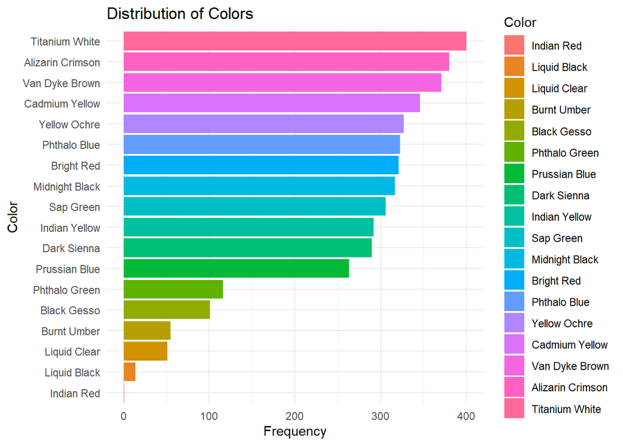

```r
# Gathering data relevant to our analyses
bob_ross_long <- bob_ross %>%
  select(painting_index, season, episode, painting_title, Black_Gesso:Alizarin_Crimson) %>%
  pivot_longer(cols = Black_Gesso:Alizarin_Crimson, names_to = "Color", values_to = "Used") %>%
  filter(Used) %>%
  mutate(Color = str_replace_all(Color, "_", " "))

# Plotting the colors by how often they are used
bob_ross_long %>%
  count(Color, sort = TRUE) %>%
  mutate(Color = fct_reorder(Color, n)) %>%
  ggplot(aes(Color, n, fill = Color)) +
  geom_col() +
  labs(title = "Distribution of Colors",
       x = "Color",
       y = "Frequency") +
  coord_flip()
```

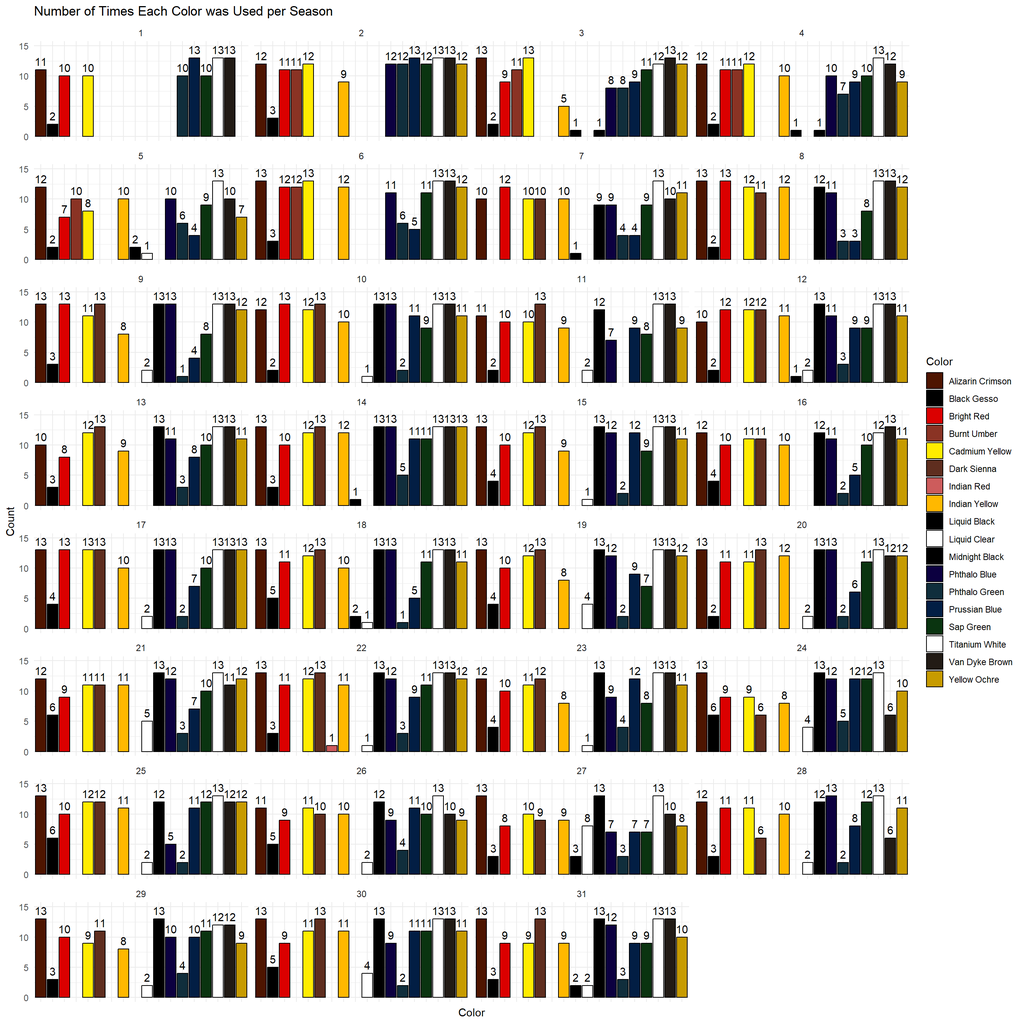

```r
# Plotting the colors used by season
ggplot(bob_ross_long, aes(x = Color, fill = Color)) +
  geom_bar(color = "black", position = "dodge") +
  geom_text(stat = 'count', aes(label = after_stat(count)), vjust = -.5) +
  expand_limits(y = 15) +
  labs(title = "Number of Times Each Color was Used per Season",
       x = "Color",
       y = "Count") +
  theme_minimal() +
  theme(axis.text.x = element_blank()) +
  facet_wrap(~ season, ncol = 4) +
  scale_fill_manual(values = hex_color)
```

```
## `geom_line()`: Each group consists of only one observation.
## ℹ Do you need to adjust the group aesthetic?
```

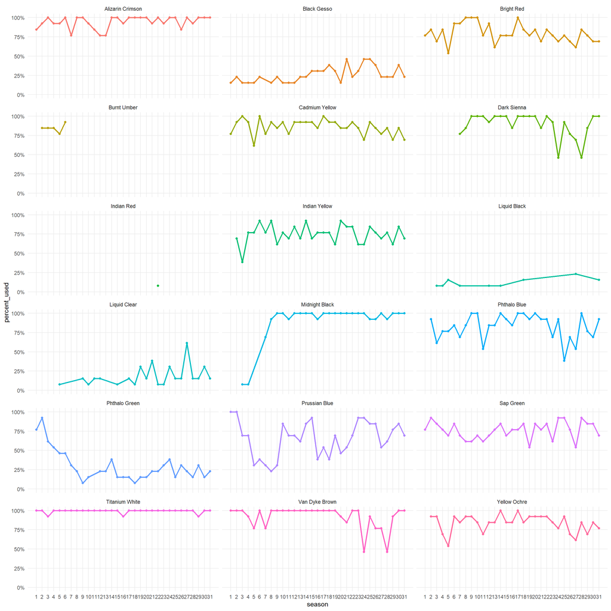

```r
# Plotting percentage of times each color was used in each season
by_color <- bob_ross_long %>%
  group_by(season) %>%
  mutate(number_episode = n_distinct(episode)) %>%
  count(season, Color, number_episode, sort = TRUE) %>%
  mutate(percent_used = n / number_episode) %>%
  group_by(Color) %>%
  mutate(total_color = sum(n)) %>%
  ungroup()


ggplot(by_color, aes(season, percent_used, color = Color)) +
  geom_point(show.legend = FALSE) +
  geom_line(size = 1, show.legend = FALSE) +
  scale_y_continuous(labels = scales::percent_format()) +
  expand_limits(y = 0) +
  facet_wrap(~ Color, ncol = 3) +
  scale_x_continuous(breaks = 1:31, limits = c(1, 31)) +
  theme(panel.grid.minor.y = element_blank(),
        panel.grid.minor.x = element_blank())
```

This shows us the color trends by color and we can see some patterns emerging such as Phthalo Green becoming less used after the earlier seasons and Midnight Blue becoming more used after season 4.

It seems that Burnt Umber was replaced with midnight black at season 6.

The usage pattern of Cadmium Yellow, Yellow Ochre, and Indian Yellow seem pretty similar as well.

Therefore, we would check the correlation of the usage of each color with each other.

## Correlation

```r
# Checking Correlation of each color
correlation <- bob_ross_long %>%
  add_count(Color) %>%
  pairwise_cor(Color, painting_index, sort = TRUE)
kable(correlation, digits = 3)
```

| item1 | item2 | correlation |
| --- | --- | --- |
| Dark Sienna | Midnight Black | 0.780 |
| Midnight Black | Dark Sienna | 0.780 |
| Yellow Ochre | Indian Yellow | 0.583 |
| Indian Yellow | Yellow Ochre | 0.583 |
| Yellow Ochre | Cadmium Yellow | 0.551 |
| Cadmium Yellow | Yellow Ochre | 0.551 |
| Sap Green | Cadmium Yellow | 0.538 |
| Cadmium Yellow | Sap Green | 0.538 |
| Indian Yellow | Sap Green | 0.523 |
| Sap Green | Indian Yellow | 0.523 |
| Indian Yellow | Cadmium Yellow | 0.499 |
| Cadmium Yellow | Indian Yellow | 0.499 |
| Yellow Ochre | Sap Green | 0.485 |
| Sap Green | Yellow Ochre | 0.485 |
| Cadmium Yellow | Bright Red | 0.485 |
| Bright Red | Cadmium Yellow | 0.485 |
| Yellow Ochre | Bright Red | 0.465 |
| Bright Red | Yellow Ochre | 0.465 |
| Indian Yellow | Bright Red | 0.433 |
| Bright Red | Indian Yellow | 0.433 |
| Dark Sienna | Van Dyke Brown | 0.430 |
| Van Dyke Brown | Dark Sienna | 0.430 |
| Sap Green | Bright Red | 0.379 |
| Bright Red | Sap Green | 0.379 |
| Yellow Ochre | Phthalo Blue | 0.317 |
| Phthalo Blue | Yellow Ochre | 0.317 |
| Dark Sienna | Yellow Ochre | 0.306 |
| Yellow Ochre | Dark Sienna | 0.306 |
| Burnt Umber | Phthalo Green | 0.274 |
| Phthalo Green | Burnt Umber | 0.274 |

[output cut: 276 more lines]

The correlation between Burnt Umber and Midnight Black is the lowest amonst all the colors at -0.728. Which suggests that when one of these two colors was used, the other colors was less likely to be used.

The correlation between Dark Sienna and Midnight Black was the highest at 0.780. This suggests that they were frequently used together.

We see Yellow Ochre and Indian Yellow correlates with each other moderately with a 0.583 correlation. Cadmium Yellow and Yellow Ochre also correlated moderately at 0.551.Additionally the correaltion between Indian Yellow and Cadmium Yellow is 0.499 which is also a moderate correlation. This suggests that these colors were used pretty frequently together.

With this, we can start analyzing if clusters of colors exist

```
## Using "stress" as default layout
```

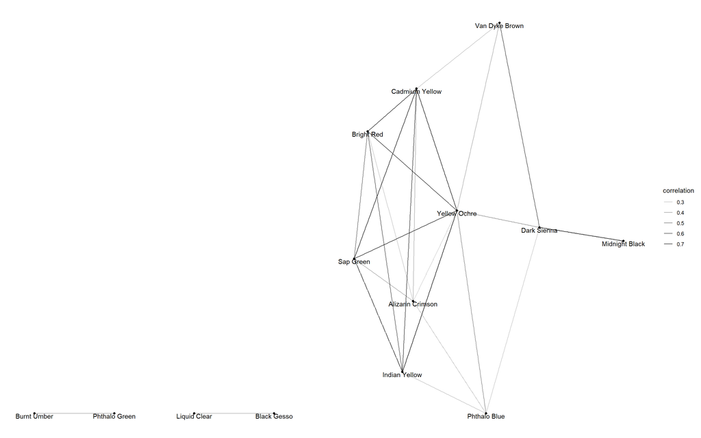

```r
correlation %>%
  head(50) %>%
  graph_from_data_frame() %>%
  ggraph() +
  geom_edge_link(aes(alpha = correlation)) +
  geom_node_point() +
  geom_node_text(aes(label = name), vjust = 1, hjust = .5)
```

Now we can see some clusters of colors.

We can see one cluster of darker brown tonned colors correlating moderately with each other on the right consisting of Van Dyke Brown, Dark Sienna, and Midnight Black.

We can also see a whole cluster of color with the 3 aforementioned yellows (Cadmium Yellow, Yellow Ochro, and Indian Yellow) with some additions of reds and greens (Bright Red, Alizarin Crimson, and Sap Green). These are the brighter colors (apart from the whites) that Bob Ross uses.